# Introduction to Statistics in Python

Lecturers: Maggie Matsui

It is recommended that you take the course [**Data Manipulation with Pandas** prior to this course.](https://quannguyeniu.github.io/DataCamp/Python/Data_Manipulation_Pandas.html)

# 1 Course Description

Statistics is the study of how to collect, analyze, and draw conclusions from data. It’s a hugely valuable tool that you can use to bring the future into focus and infer the answer to tons of questions. For example, what is the likelihood of someone purchasing your product, how many calls will your support team receive, and how many jeans sizes should you manufacture to fit 95% of the population? In this course, you’ll discover how to answer questions like these as you grow your statistical skills and learn how to calculate averages, use scatterplots to show the relationship between numeric values, and calculate correlation. You’ll also tackle probability, the backbone of statistical reasoning, and learn how to use Python to conduct a well-designed study to draw your own conclusions from data.

Course materials can be found [**here**.](https://github.com/QuanNguyenIU/QuanNguyenIU.github.io/tree/main/DataCamp/Python/Intro.%20to%20Statistics%20in%20Python)

# 2 Summary Statistics

Summary statistics gives you the tools you need to boil down massive datasets to reveal the highlights. In this chapter, you’ll explore summary statistics including mean, median, and standard deviation, and learn how to accurately interpret them. You’ll also develop your critical thinking skills, allowing you to choose the best summary statistics for your data.

## 2.1 What is statistics?

[video not shown]

## 2.2 Measures of center

[video not shown]

## 2.3 Mean and median

In this chapter, you’ll be working with the food_consumption dataset from [**2018 Food Carbon Footprint Index** by nu3. The food_consumption dataset contains the number of kilograms of food consumed per person per year in each country and food category (consumption), and its carbon footprint (co2_emissions) measured in kilograms of carbon dioxide, or CO2.](https://cdnssl.nu3.de/lpb/2018/05/Food-Carbon-Footprint-Index-2018.pdf)

In this exercise, you’ll compute measures of center to compare food consumption in the US and Belgium using your pandas and numpy skills.

```python
import pandas as pd
url = 'https://raw.githubusercontent.com/QuanNguyenIU/QuanNguyenIU.github.io/main/DataCamp/Python/Intro.%20to%20Statistics%20in%20Python/food_consumption.csv'
food_consumption = pd.read_csv(url)

# Import numpy with alias np
import numpy as np

# Subset country for USA: usa_consumption
usa_consumption = food_consumption[food_consumption['country'] == 'USA']

# Calculate mean consumption in USA
print(usa_consumption['consumption'].mean())
```

```
## 44.650000000000006
```

```python
# Calculate median consumption in USA
print(usa_consumption['consumption'].median())
```

```
## 14.58
```

The calculations show that the mean (44.65) and median (14.58) consumption in the US are quite different. This large gap suggests the data may be skewed - let’s explore the distribution to understand why.

## 2.4 Mean vs. median

In the video, you learned that the mean is the sum of all the data points divided by the total number of data points, and the median is the middle value of the dataset where 50% of the data is less than the median, and 50% of the data is greater than the median. In this exercise, you’ll compare these two measures of center.

```python
# Import matplotlib.pyplot with alias plt
import matplotlib.pyplot as plt

# Subset for food_category equals rice
rice_consumption = food_consumption[food_consumption.food_category == 'rice']

# Calculate mean and median of co2_emission with .agg()
print(rice_consumption.co2_emission.agg([np.mean,np.median]))
```

```
## mean      37.591615
## median    15.200000
## Name: co2_emission, dtype: float64
```

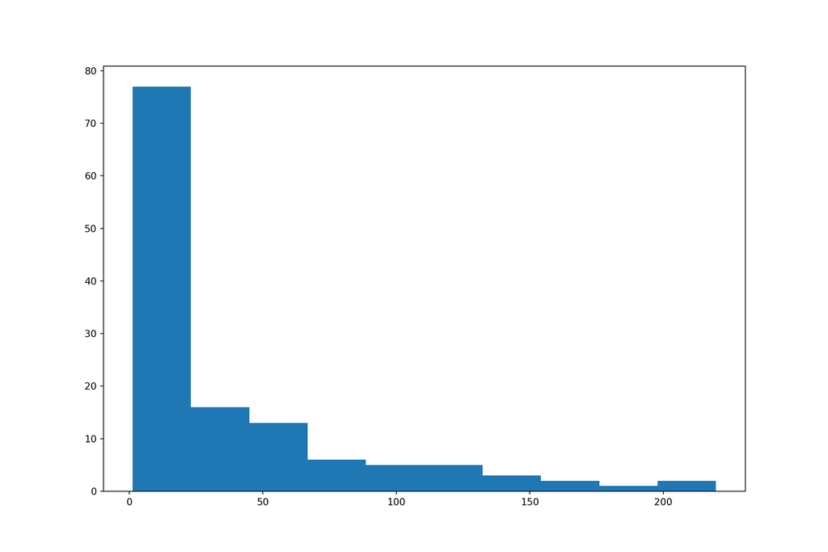

```python
# Histogram of co2_emission for rice and show plot
plt.hist(rice_consumption.co2_emission)
plt.show()
```

The mean (37.6) is pulled up by countries with high rice consumption, while the median (15.2) better represents the typical value for right-skewed data.

## 2.5 Measures of spread

[video not shown]

## 2.6 Variance and standard deviation

Variance and standard deviation are two of the most common ways to measure the spread of a variable, and you’ll practice calculating these in this exercise. Spread is important since it can help inform expectations. For example, if a salesperson sells a mean of 20 products a day, but has a standard deviation of 10 products, there will probably be days where they sell 40 products, but also days where they only sell one or two. Information like this is important, especially when making predictions.

```python
# Print variance and sd of co2_emission for each food_category
print(food_consumption.groupby('food_category')['co2_emission'].agg([np.var, np.std]))
```

```
##                         var         std
## food_category
## beef           88065.728070  296.758703
## dairy          17535.954354  132.423391
## eggs              21.207421    4.605152
## fish             914.547831   30.241492
## lamb_goat      16348.783606  127.862362
## nuts              35.365501    5.946890
## pork            3071.156125   55.418013
## poultry          243.141980   15.593011
## rice            2263.827195   47.579693
## soybeans           0.873114    0.934405
## wheat             70.477599    8.395094
```

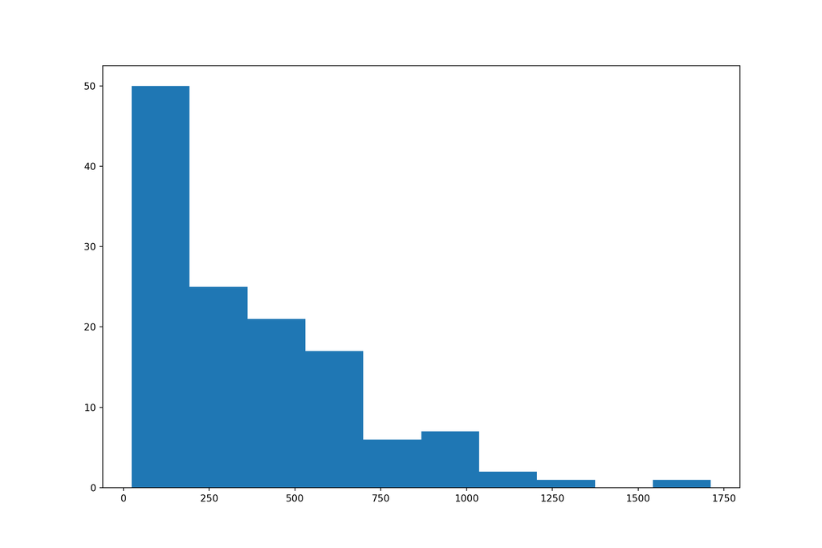

```python
# Create histogram of co2_emission for food_category 'beef'
plt.hist(food_consumption[food_consumption.food_category == 'beef'].co2_emission)
# Show plot
plt.show()
```

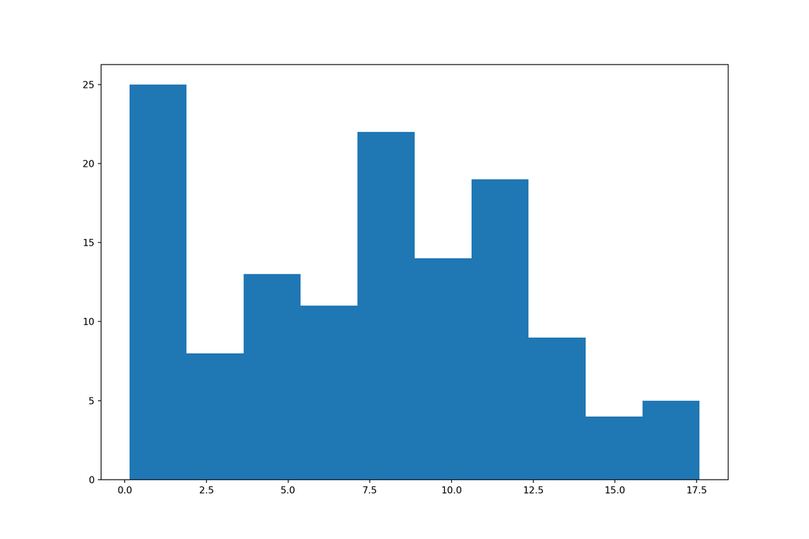

```python
# Create histogram of co2_emission for food_category 'eggs'
plt.hist(food_consumption[food_consumption.food_category == 'eggs'].co2_emission)
# Show plot
plt.show()
```

## 2.7 Quartiles, quantiles, and quintiles

Quantiles are a great way of summarizing numerical data since they can be used to measure center and spread, as well as to get a sense of where a data point stands in relation to the rest of the data set. For example, you might want to give a discount to the 10% most active users on a website.

In this exercise, you’ll calculate quartiles, quintiles, and deciles, which split up a dataset into 4, 5, and 10 pieces, respectively.

```python
# Calculate the quartiles of co2_emission
print(np.quantile(food_consumption.co2_emission, q = [0, 0.25, 0.5, 0.75, 1]))
```

```
## [   0.        5.21     16.53     62.5975 1712.    ]
```

```python
# Calculate the quintiles of co2_emission
print(np.quantile(food_consumption.co2_emission, q = [0, 0.2, 0.4, 0.6, 0.8, 1]))
```

```
## [   0.       3.54    11.026   25.59    99.978 1712.   ]
```

```python
# Calculate the deciles of co2_emission
print(np.quantile(food_consumption.co2_emission, q = np.linspace(0, 1, 11)))
```

```
## [0.00000e+00 6.68000e-01 3.54000e+00 7.04000e+00 1.10260e+01 1.65300e+01
##  2.55900e+01 4.42710e+01 9.99780e+01 2.03629e+02 1.71200e+03]
```

While calculating more quantiles gives you a more detailed look at the data, it also produces more numbers, making the summary more difficult to quickly understand.

## 2.8 Finding outliers using IQR

Outliers can have big effects on statistics like mean, as well as statistics that rely on the mean, such as variance and standard deviation. Interquartile range, or IQR, is another way of measuring spread that’s less influenced by outliers. IQR is also often used to find outliers. If a value is less than $Q1-1.5\times IQR$ or greater than $Q3+1.5\times IQR$, it’s considered an outlier. In fact, this is how the lengths of the whiskers in a matplotlib box plot are calculated.

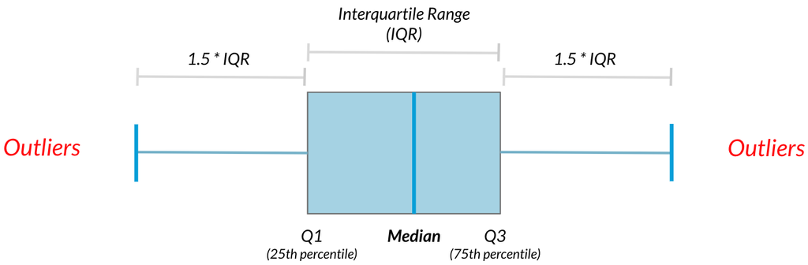

```python
# Calculate total co2_emission per country: emissions_by_country
emissions_by_country = food_consumption.groupby('country')['co2_emission'].sum()

# Compute the first and third quantiles and IQR of emissions_by_country
q1 = np.quantile(emissions_by_country, 0.25)
q3 = np.quantile(emissions_by_country, 0.75)
iqr = q3 - q1

# Calculate the lower and upper cutoffs for outliers
lower = q1 - 1.5 * iqr
upper = q3 + 1.5 * iqr

# Subset emissions_by_country to find outliers
outliers = emissions_by_country[emissions_by_country > upper]
print(outliers)
```

```
## country
## Argentina    2172.4
## Name: co2_emission, dtype: float64
```

It looks like Argentina has a substantially higher amount of CO2 emissions per person than other countries in the world.

# 3 Random Numbers and Probability

In this chapter, you’ll learn how to generate random samples and measure chance using probability. You’ll work with real-world sales data to calculate the probability of a salesperson being successful. Finally, you’ll use the binomial distribution to model events with binary outcomes.

## 3.1 What are the chances?

[video not shown]

## 3.2 Calculating probabilities

You’re in charge of the sales team, and it’s time for performance reviews, starting with Amir. As part of the review, you want to randomly select a few of the deals that he’s worked on over the past year so that you can look at them more deeply. Before you start selecting deals, you’ll first figure out what the chances are of selecting certain deals.

Recall that the probability of an event can be calculated by
$$P(event)=\frac{\#\ ways\ event\ can\
happen}{total\ \#\ of\ possible\ outcomes}$$

```python
url = 'https://raw.githubusercontent.com/QuanNguyenIU/QuanNguyenIU.github.io/main/DataCamp/Python/Intro.%20to%20Statistics%20in%20Python/amir_deals.csv'
amir_deals = pd.read_csv(url)

# Count the deals for each product
counts = amir_deals['product'].value_counts()

# Calculate probability of picking a deal with each product
probs = counts / sum(list(counts))
print(probs)
```

```
## product
## Product B    0.348315
## Product D    0.224719
## Product A    0.129213
## Product C    0.084270
## Product F    0.061798
## Product H    0.044944
## Product I    0.039326
## Product E    0.028090
## Product N    0.016854
## Product G    0.011236
## Product J    0.011236
## Name: count, dtype: float64
```

Now that you know what the chances are, it’s time to start sampling.

## 3.3 Sampling deals

In the previous exercise, you counted the deals Amir worked on. Now it’s time to randomly pick five deals so that you can reach out to each customer and ask if they were satisfied with the service they received. You’ll try doing this both with and without replacement.

Additionally, you want to make sure this is done randomly and that it can be reproduced in case you get asked how you chose the deals, so you’ll need to set the random seed before sampling from the deals.

```python
# Set random seed
np.random.seed(24)

# Sample 5 deals without replacement
sample_without_replacement = amir_deals.sample(5)
print(sample_without_replacement)
```

```
##      Unnamed: 0    product   client status   amount  num_users
## 127         128  Product B  Current    Won  2070.25          7
## 148         149  Product D  Current    Won  3485.48         52
## 77           78  Product B  Current    Won  6252.30         27
## 104         105  Product D  Current    Won  4110.98         39
## 166         167  Product C      New   Lost  3779.86         11
```

```python
# Sample 5 deals with replacement
sample_with_replacement = amir_deals.sample(5, replace =True)
print(sample_with_replacement)
```

```
##      Unnamed: 0    product   client status   amount  num_users
## 133         134  Product D  Current    Won  5992.86         98
## 101         102  Product H  Current    Won  5116.34         63
## 110         111  Product B  Current    Won   696.88         44
## 49           50  Product B  Current    Won  3488.36         79
## 56           57  Product D  Current    Won  6820.84         42
```

It’s important to consider how you’ll take a sample since there’s no one-size-fits-all way to sample, and this can have an effect on your results.

## 3.4 Discrete distributions

[video not shown]

## 3.5 Creating a probability distribution

A new restaurant opened a few months ago, and the restaurant’s management wants to optimize its seating space based on the size of the groups that come most often. On one night, there are 10 groups of people waiting to be seated at the restaurant, but instead of being called in the order they arrived, they will be called randomly. In this exercise, you’ll investigate the probability of groups of different sizes getting picked first. Data on each of the ten groups is contained in the restaurant_groups DataFrame.

Remember that expected value can be calculated by multiplying each possible outcome with its corresponding probability and taking the sum.

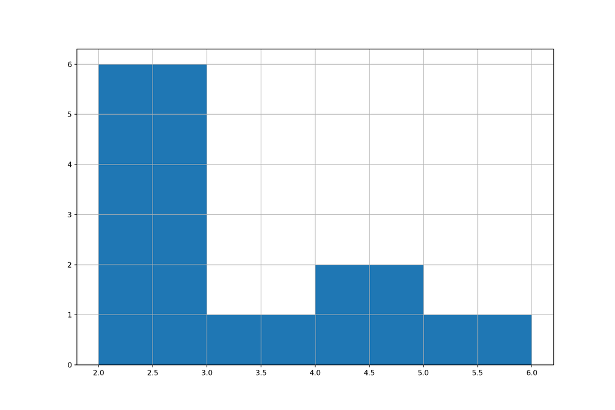

```python
url = 'https://raw.githubusercontent.com/QuanNguyenIU/QuanNguyenIU.github.io/main/DataCamp/Python/Intro.%20to%20Statistics%20in%20Python/restaurant_groups.csv'
restaurant_groups = pd.read_csv(url)

# Create a histogram of restaurant_groups and show plot
restaurant_groups['group_size'].hist(bins=[2, 3, 4, 5, 6])
plt.show()
```

```python
# Create probability distribution
size_dist = restaurant_groups.groupby('group_size').agg(len) / len(restaurant_groups)

# Reset index and rename columns
size_dist = size_dist.reset_index()
size_dist.columns = ['group_size', 'prob']

print(size_dist)
```

```
##    group_size  prob
## 0           2   0.6
## 1           3   0.1
## 2           4   0.2
## 3           6   0.1
```

```python
# Calculate expected value
expected_value = sum(size_dist.group_size * size_dist.prob)
print(expected_value)
```

```
## 2.9000000000000004
```

```python
# Subset groups of size 4 or more
groups_4_or_more = size_dist[size_dist['group_size'] >= 4]

# Sum the probabilities of groups_4_or_more
prob_4_or_more = np.sum(groups_4_or_more['prob'])
print(prob_4_or_more)
```

```
## 0.30000000000000004
```

You’ll continue to build upon these skills since many statistical tests and methods use probability distributions as their foundation.

## 3.6 Continuous distributions

[video not shown]

## 3.7 Data back-ups

The sales software used at your company is set to automatically back itself up, but no one knows exactly what time the back-ups happen. It is known, however, that back-ups happen exactly every 30 minutes. Amir comes back from sales meetings at random times to update the data on the client he just met with. He wants to know how long he’ll have to wait for his newly-entered data to get backed up. Use your new knowledge of continuous uniform distributions to model this situation and answer Amir’s questions.

```python
# Min and max wait times for back-up that happens every 30 min
min_time = 0
max_time = 30

# Import uniform from scipy.stats
from scipy.stats import uniform

# Calculate probability of waiting less than 5 mins
dist = uniform(loc = min_time, scale = max_time - min_time)
prob_less_than_5 = dist.cdf(5)
print(prob_less_than_5)
```

```
## 0.16666666666666666
```

```python
# Calculate probability of waiting more than 5 mins
prob_greater_than_5 = 1 - dist.cdf(5)
print(prob_greater_than_5)
```

```
## 0.8333333333333334
```

```python
# Calculate probability of waiting 10-20 mins
prob_between_10_and_20 = dist.cdf(20) - dist.cdf(10)
print(prob_between_10_and_20)
```

```
## 0.3333333333333333
```

In the next exercise, you’ll make sure this calculation holds up by simulating some wait times.

## 3.8 Simulating wait times

To give Amir a better idea of how long he’ll have to wait, you’ll simulate Amir waiting 1000 times and create a histogram to show him what he should expect. Recall from the last exercise that his minimum wait time is 0 minutes and his maximum wait time is 30 minutes.

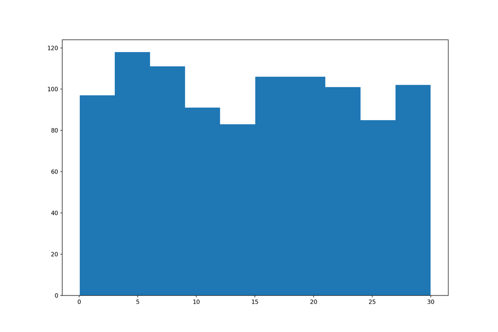

```python
# Set random seed to 334
np.random.seed(334)

# Generate 1000 wait times between 0 and 30 mins
wait_times = uniform.rvs(min_time, max_time, size = 1000)

# Create a histogram of simulated times and show plot
plt.hist(wait_times)
plt.show()
```

Unless Amir figures out exactly what time each backup happens, he won’t be able to time his data entry so it gets backed up sooner, but it looks like he’ll wait about 15 minutes on average.

## 3.9 The binomial distribution

[video not shown]

## 3.10 Simulating sales deals

Assume that Amir usually works on 3 deals per week, and overall, he wins 30% of deals he works on. Each deal has a binary outcome: it’s either lost, or won, so you can model his sales deals with a binomial distribution. In this exercise, you’ll help Amir simulate a year’s worth of his deals so he can better understand his performance.

```python
# Import binom from scipy.stats
from scipy.stats import binom

# Set random seed to 10
np.random.seed(10)

# Simulate a single deal
print(binom.rvs(1, 0.3, size = 1))
```

```
## [1]
```

```python
# Simulate 1 week of 3 deals
print(binom.rvs(3, 0.3, size = 1))
```

```
## [0]
```

```python
# Simulate 52 weeks of 3 deals
deals = binom.rvs(3, 0.3, size = 52)

# Print mean deals won per week
print(deals.mean())
```

```
## 0.8461538461538461
```

## 3.11 Calculating binomial probabilities

Just as in the last exercise, assume that Amir wins 30% of deals. He wants to get an idea of how likely he is to close a certain number of deals each week. In this exercise, you’ll calculate what the chances are of him closing different numbers of deals using the binomial distribution.

```python
# Probability of closing 3 out of 3 deals
prob_3 = 0.3 ** 3

print(prob_3)
```

```
## 0.026999999999999996
```

```python
# Probability of closing <= 1 deal out of 3 deals
prob_less_than_or_equal_1 = binom.cdf(1,3,0.3)

print(prob_less_than_or_equal_1)
```

```
## 0.784
```

```python
# Probability of closing > 1 deal out of 3 deals
prob_greater_than_1 = 1-binom.cdf(1,3,0.3)

print(prob_greater_than_1)
```

```
## 0.21599999999999997
```

## 3.12 How many sales will be won?

Now Amir wants to know how many deals he can expect to close each week if his win rate changes. Luckily, you can use your binomial distribution knowledge to help him calculate the expected value in different situations. Recall from the video that the expected value of a binomial distribution can be calculated by $n\times p$.

```python
# Expected number won with 30% win rate
won_30pct = binom.mean(3, 0.3)
print(won_30pct)
```

```
## 0.8999999999999999
```

```python
# Expected number won with 25% win rate
won_25pct = binom.mean(3, 0.25)
print(won_25pct)
```

```
## 0.75
```

```python
# Expected number won with 35% win rate
won_35pct = binom.mean(3, 0.35)
print(won_35pct)
```

```
## 1.0499999999999998
```

If Amir’s win rate goes up by 5%, he can expect to close more than 1 deal on average each week.

# 4 More Distributions and the Central Limit Theorem

It’s time to explore one of the most important probability distributions in statistics, normal distribution. You’ll create histograms to plot normal distributions and gain an understanding of the central limit theorem, before expanding your knowledge of statistical functions by adding the Poisson, exponential, and t-distributions to your repertoire.

## 4.1 The normal distribution

[video not shown]

## 4.2 Distribution of Amir’s sales

Since each deal Amir worked on (both won and lost) was different, each was worth a different amount of money. These values are stored in the amount column of amir_deals As part of Amir’s performance review, you want to be able to estimate the probability of him selling different amounts, but before you can do this, you’ll need to determine what kind of distribution the amount variable follows.

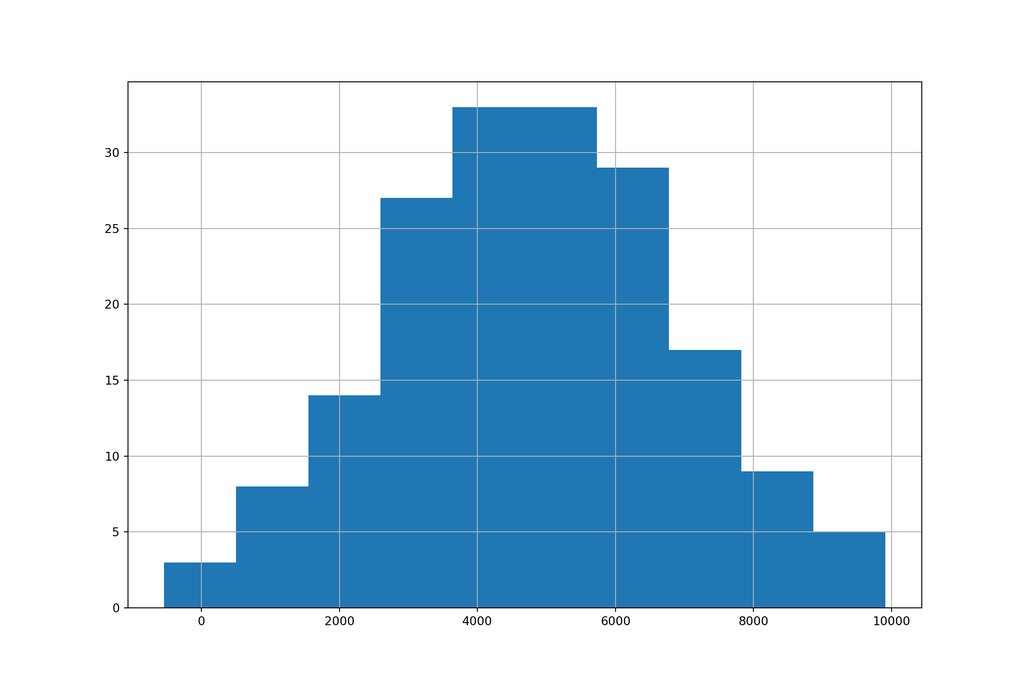

```python
# Histogram of amount with 10 bins and show plot
amir_deals['amount'].hist(bins = 10)
plt.show()
```

Now that you’ve visualized the data, you know that you can approximate probabilities of different amounts using the normal distribution.

## 4.3 Probabilities from the normal distribution

Since each deal Amir worked on (both won and lost) was different, each was worth a different amount of money. These values are stored in the amount column of amir_deals and follow a normal distribution with a mean of 5000 dollars and a standard deviation of 2000 dollars. As part of his performance metrics, you want to calculate the probability of Amir closing a deal worth various amounts.

```python
from scipy.stats import norm

# Probability of deal < 7500
prob_less_7500 = norm.cdf(7500, 5000, 2000)

print(prob_less_7500)
```

```
## 0.8943502263331446
```

```python
# Probability of deal > 1000
prob_over_1000 = 1-norm.cdf(1000, 5000, 2000)

print(prob_over_1000)
```

```
## 0.9772498680518208
```

```python
# Probability of deal between 3000 and 7000
prob_3000_to_7000 = norm.cdf(7000, 5000, 2000) - norm.cdf(3000, 5000, 2000)

print(prob_3000_to_7000)
```

```
## 0.6826894921370859
```

```python
# Calculate amount that 25% of deals will be less than
pct_25 = norm.ppf(0.25, 5000, 2000)

print(pct_25)
```

```
## 3651.0204996078364
```

You know that you can count on Amir 75% (1-0.25) of the time to make a sale worth at least $3651.02. This information could be useful in making company-wide sales projections.

## 4.4 Simulating sales under new market conditions

The company’s financial analyst is predicting that next quarter, the worth of each sale will increase by 20% and the volatility, or standard deviation, of each sale’s worth will increase by 30%. To see what Amir’s sales might look like next quarter under these new market conditions, you’ll simulate new sales amounts using the normal distribution and store these in the new_sales DataFrame.

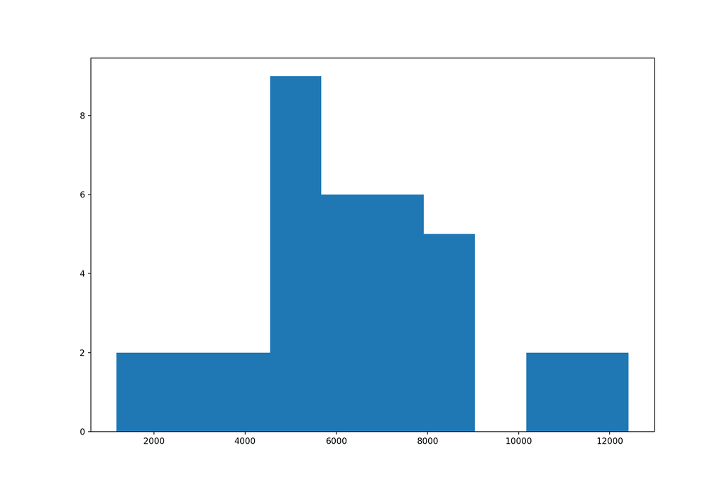

```python
# Calculate new average amount
new_mean = 5000 * 1.2

# Calculate new standard deviation
new_sd = 2000 * 1.3

# Simulate 36 new sales
new_sales = norm.rvs(new_mean, new_sd, size = 36)

# Create histogram and show
plt.hist(new_sales)
plt.show()
```

Although the average sale amount went up, the variation also increased, so it’s not straightforward to decide whether these sales are better than his current ones.

## 4.5 The central limit theorem

[video not shown]

## 4.6 The CLT in action

The central limit theorem states that a sampling distribution of a sample statistic approaches the normal distribution as you take more samples, no matter the original distribution being sampled from.

In this exercise, you’ll focus on the sample mean and see the central limit theorem in action while examining the num_users column of amir_deals more closely, which contains the number of people who intend to use the product Amir is selling.

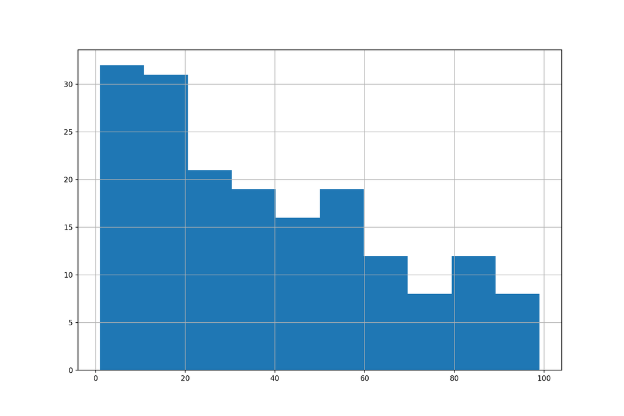

```python
# Create a histogram of num_users and show
amir_deals['num_users'].hist()
plt.show()
```

```python
# Set seed to 104
np.random.seed(104)

# Sample 20 num_users with replacement from amir_deals
samp_20 = amir_deals['num_users'].sample(20, replace = True)

# Take mean of samp_20
print(np.mean(samp_20))
```

```
## 32.0
```

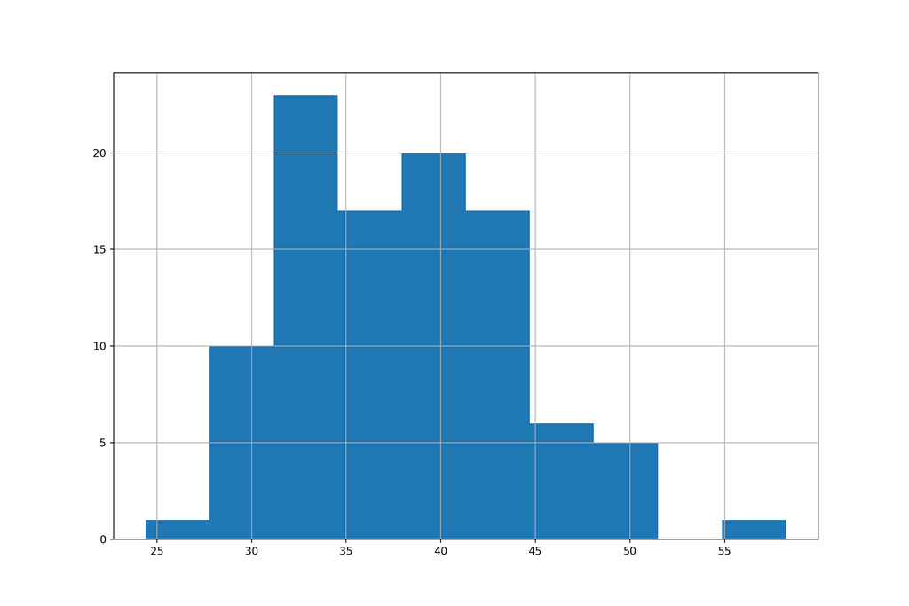

```python
sample_means = []
# Loop 100 times
for i in range(100):
  # Take sample of 20 num_users
  samp_20 = amir_deals['num_users'].sample(20, replace = True)

  # Calculate mean of samp_20
  samp_20_mean = np.mean(samp_20)
  # Append samp_20_mean to sample_means
  sample_means.append(samp_20_mean)

# Convert to Series and plot histogram
sample_means_series = pd.Series(sample_means)
sample_means_series.hist()
# Show plot
plt.show()
```

You’ve just seen the central limit thorem at work. Even though the distribution of num_users is not normal, the distribution of its sample means resembles the normal distribution.

## 4.7 The mean of means

You want to know what the average number of users (num_users) is per deal, but you want to know this number for the entire company so that you can see if Amir’s deals have more or fewer users than the company’s average deal. The problem is that over the past year, the company has worked on more than ten thousand deals, so it’s not realistic to compile all the data. Instead, you’ll estimate the mean by taking several random samples of deals, since this is much easier than collecting data from everyone in the company. The user data for all the company’s deals is available in all_deals.

```python
url = 'https://raw.githubusercontent.com/QuanNguyenIU/QuanNguyenIU.github.io/main/DataCamp/Python/Intro.%20to%20Statistics%20in%20Python/all_deals.csv'
all_deals = pd.read_csv(url)

# Set seed to 321
np.random.seed(321)

sample_means = []
# Loop 30 times to take 30 means
for i in range(30):
  # Take sample of size 20 from num_users col of all_deals with replacement
  cur_sample = np.random.choice(all_deals['num_users'],
                                size = 20, replace = True)
  # Take mean of cur_sample
  cur_mean = np.mean(cur_sample)
  # Append cur_mean to sample_means
  sample_means.append(cur_mean)

# Print mean of sample_means
print(np.mean(sample_means))
```

```
## 38.31333333333332
```

```python
# Print mean of num_users in amir_deals
print(amir_deals['num_users'].mean())
```

```
## 37.651685393258425
```

Amir’s average number of users is very close to the overall average, so it looks like he’s meeting expectations. Make sure to note this in his performance review!

## 4.8 The Poisson distribution

[video not shown]

## 4.9 Tracking lead responses

Your company uses sales software to keep track of new sales leads. It organizes them into a queue so that anyone can follow up on one when they have a bit of free time. Since the number of lead responses is a countable outcome over a period of time, this scenario corresponds to a Poisson distribution. On average, Amir responds to 4 leads each day. In this exercise, you’ll calculate probabilities of Amir responding to different numbers of leads.

```python
# Import poisson from scipy.stats
from scipy.stats import poisson

# calculate the probability that Amir responds to 5 leads in a day,
# given that he responds to an average of 4.
prob_5 = poisson.pmf(5, 4)

print(prob_5)
```

```
## 0.1562934518505317
```

```python
# Probability of 2 or fewer responses
prob_2_or_less = poisson.cdf(2, 4)

print(prob_2_or_less)
```

```
## 0.23810330555354436
```

```python
# Probability of > 10 responses
prob_over_10 = 1 - poisson.cdf(10, 4)

print(prob_over_10)
```

```
## 0.0028397661205137315
```

```python
# Amir's coworker responds to an average of 5.5 leads per day.
# What is the probability that she answers 5 leads in a day?
prob_coworker = poisson.pmf(5, 5.5)

print(prob_coworker)
```

```
## 0.17140068409793663
```

Note that if you provide poisson.pmf() or poisson.cdf() with a non-integer, it throws an error since the Poisson distribution only applies to integers.

## 4.10 More probability distributions

[video not shown]

## 4.11 Modeling time between leads

To further evaluate Amir’s performance, you want to know how much time it takes him to respond to a lead after he opens it. On average, he responds to 1 request every 2.5 hours. In this exercise, you’ll calculate probabilities of different amounts of time passing between Amir receiving a lead and sending a response.

```python
# Import expon from scipy.stats
from scipy.stats import expon

# Print probability response takes < 1 hour
print(expon.cdf(1, scale = 2.5))
```

```
## 0.3296799539643607
```

```python
# Print probability response takes > 4 hours
print(1 - expon.cdf(4, scale = 2.5))
```

```
## 0.20189651799465536
```

```python
# Print probability response takes 3-4 hours
print(expon.cdf(4, scale = 2.5) - expon.cdf(3, scale = 2.5))
```

```
## 0.09929769391754684
```

There’s only about a 20% chance it will take Amir more than 4 hours to respond, so he’s pretty speedy in his responses.

# 5 Correlation and Experimental Design

In this chapter, you’ll learn how to quantify the strength of a linear relationship between two variables, and explore how confounding variables can affect the relationship between two other variables. You’ll also see how a study’s design can influence its results, change how the data should be analyzed, and potentially affect the reliability of your conclusions.

## 5.1 Correlation

[video not shown]

## 5.2 Relationships between variables

## 5.3 Correlation caveats

[video not shown]

## 5.4 What can’t correlation measure?

## 5.5 Transforming variables

## 5.6 Does sugar improve happiness?

## 5.7 Design of experiments

[video not shown]

# 6 Course Recap

[video not shown]

Congratulations on completing the course! More courses, tracks and instructions can be found [**here**. Happy learning!](https://quannguyeniu.github.io/DataCamp/master.html)